# Selecting A Journal

## Master Journal List Beta

https://apps.clarivate.com/mjl-beta/search-results

- Browse, search, and explore journals indexed in the Web of Science
- Master Journal List Beta is the definitive guide that allows you to search for journals indexed in the Web of Science. Explore more than 24,000 journals across the sciences, social sciences, and arts and humanities and discover key metrics and information using our new journal profile pages.
- Already have a manuscript?
- Find journals where your research is most likely to be accepted based on an analysis of tens of millions of citation connections in Web of Science Core Collection using Manuscript Matcher.

## Selecting A Journal

- [Think Check Submit](https://thinkchecksubmit.org/)

https://vimeo.com/151882443/recommended

https://thinkchecksubmit.org

- Master Journal List

http://ip-science.thomsonreuters.com/cgi-bin/jrnlst/jloptions.cgi?PC=D

- Springer Journal Suggester

http://journalsuggester.springer.com/

- JANE: Journal/Author Name Estimator

http://jane.biosemantics.org/

[Schuemie, Martijn J. and Jan A. Kors. “Jane: suggesting journals, finding experts.” _Bioinformatics _24 5 (2008): 727-8.](https://www.semanticscholar.org/paper/Jane-suggesting-journals-finding-experts-Schuemie-Kors/1a32dc12351667a021a1afffbb053282083b29b8)

- Recommend Journals Find the right journals for your unpublished article

http://www.sjfinder.com/journals/recommend

- Find Journals Discover journals within your field of study

http://www.sjfinder.com/journals/home

- Journal Selector

https://www.edanzediting.com/journal-selector

- Elsevier Journal Finder

http://journalfinder.elsevier.com/

- Identifying Predatory or Pseudo-Journals

http://www.wame.org/about/identifying-predatory-or-pseudo-journals

- ROAD Directory of Open Access scholarly Resources

http://road.issn.org/en/contenu/purposes-road-project#.WPZ4no4lG34

- Choosing a journal

http://authorservices.taylorandfrancis.com/category/choosing-a-journal/

- Tips for finding the right journal

https://www.biomedcentral.com/getpublished/find-the-right-journal

- Directory of Open Access Journals (DOAJ)

https://doaj.org/

- Where to Publish Your Research: Identifying Potential Journals

http://guides.library.duq.edu/wheretopublish

- Journal Guide

https://www.journalguide.com/

- **An email from a lazy predatory journal:**

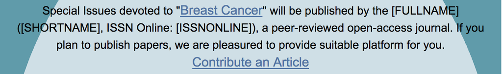

- The undercover academic keeping tabs on ‘predatory’ publishing

Following the shutdown of Beall’s list, blacklists that warn against questionable publishers are in demand

https://www.nature.com/articles/d41586-018-02921-2?WT.ec_id=NATURE-20180323

Predatory Journals diye nam salan, sizden para tırtıklayan, bilimsel kaygıdan çok daha fazla ticari kaygı ile yönetilen dergiler var. Bunları tespit etmek kolay değil. Hele yayın baskısı altında (Publish or Perish) bunların tuzağına düşmek işten bile değil. Bazen de ekmek parası uğruna “verelim parasını, kadroyu alalım” düşüncesi de oluyor.

Predatory’nin Türkçesi için ‘yırtıcı’dan daha çok ’yağmacı’ daha uygun gibi geldi bana.

Bu konuda değişik listeler ve çalışmalar var. Bunlardan birinde makale bir interaktif web sayfasına (shinyapp) dönüştürülmüş. Buradan bu dergileri arayıp bulmak mümkün:

Searching for Predatory Journals

http://www.msperlin.com/shiny/predatory/

İlgili makale:

Is predatory publishing a real threat? Evidence from a large database study

Perlin, M.S., Imasato, T. & Borenstein, D. Scientometrics (2018). https://doi.org/10.1007/s11192-018-2750-6

https://link.springer.com/article/10.1007%2Fs11192-018-2750-6

https://papers.ssrn.com/sol3/papers.cfm?abstract_id=3067958

İlgili R paketi:

predatory: Tools for Detecting Predatory Publishers and Journals

https://cran.r-project.org/web/packages/predatory/index.html

- List of Predatory Journals

https://predatoryjournals.com/

https://predatoryjournals.com/journals/

- Searching for Predatory Journals

https://www.msperlin.com/shiny/predatory/

- BİR TUHAF SAVAŞ: AÇIK BİLİM VE YAĞMACI DERGİLER

http://www.bby.hacettepe.edu.tr/akademik/zehrataskin/file/Sarkac.pdf

https://www.researchgate.net/post/Do_you_know_about_fake_journals_Ponte_Journal_is_a_hijacked_journal

http://www.pontejournal.net/ adamlar italyan bir derginin web sayfasındaki tüm bilgileri kopyalamış ve sahte bir dergi yapmışlar. sonra da para ile makale basmışlar. Dergiyi TR’den kişiler doldurmuş. Asıl Ponte dergisi bu değil. Asıl Ponte dergisi %90 italyanca yayın yapan bir dergi.

Bu ara bu konu çok fazla gündemde. ÜAK’ın kabul ettiği listeler de sürekli değişiyor.

https://cabim.ulakbim.gov.tr/tr-dizin/tr-dizinde-dizinlenen-dergi-listesi/

- **Master Journal List**

http://ip-science.thomsonreuters.com/cgi-bin/jrnlst/jloptions.cgi?PC=D

- **Springer Journal Suggester**

http://journalsuggester.springer.com/

- **JANE: Journal/Author Name Estimator**

http://jane.biosemantics.org/

[Schuemie, Martijn J. and Jan A. Kors. “Jane: suggesting journals, finding experts.” _Bioinformatics _24 5 (2008): 727-8.](https://www.semanticscholar.org/paper/Jane-suggesting-journals-finding-experts-Schuemie-Kors/1a32dc12351667a021a1afffbb053282083b29b8)

- **Recommend Journals Find the right journals for your unpublished article**

http://www.sjfinder.com/journals/recommend

- **Find Journals Discover journals within your field of study**

http://www.sjfinder.com/journals/home

- **Journal Selector**

https://www.edanzediting.com/journal-selector

- **Elsevier Journal Finder**

http://journalfinder.elsevier.com/

- **Identifying Predatory or Pseudo-Journals**

http://www.wame.org/about/identifying-predatory-or-pseudo-journals

- **ROAD Directory of Open Access scholarly Resources**

http://road.issn.org/en/contenu/purposes-road-project#.WPZ4no4lG34

- **Choosing a journal**

http://authorservices.taylorandfrancis.com/category/choosing-a-journal/

- **Tips for finding the right journal**

https://www.biomedcentral.com/getpublished/find-the-right-journal

- **Directory of Open Access Journals (DOAJ)**

https://doaj.org/

- **Where to Publish Your Research: Identifying Potential Journals**

http://guides.library.duq.edu/wheretopublish

- **An email from a lazy predatory journal:**

[figure not shown]

- The undercover academic keeping tabs on ‘predatory’ publishing

Following the shutdown of Beall’s list, blacklists that warn against questionable publishers are in demand

- **Master Journal List**

http://ip-science.thomsonreuters.com/cgi-bin/jrnlst/jloptions.cgi?PC=D

- **Springer Journal Suggester**

http://journalsuggester.springer.com/

- **JANE: Journal/Author Name Estimator**

http://jane.biosemantics.org/

[Schuemie, Martijn J. and Jan A. Kors. “Jane: suggesting journals, finding experts.” _Bioinformatics _24 5 (2008): 727-8.](https://www.semanticscholar.org/paper/Jane-suggesting-journals-finding-experts-Schuemie-Kors/1a32dc12351667a021a1afffbb053282083b29b8)

- **Recommend Journals Find the right journals for your unpublished article**

http://www.sjfinder.com/journals/recommend

- **Find Journals Discover journals within your field of study**

http://www.sjfinder.com/journals/home

- **Journal Selector**

https://www.edanzediting.com/journal-selector

- **Elsevier Journal Finder**

http://journalfinder.elsevier.com/

- **Identifying Predatory or Pseudo-Journals**

http://www.wame.org/about/identifying-predatory-or-pseudo-journals

- **ROAD Directory of Open Access scholarly Resources**

http://road.issn.org/en/contenu/purposes-road-project#.WPZ4no4lG34

- **Choosing a journal**

http://authorservices.taylorandfrancis.com/category/choosing-a-journal/

- **Tips for finding the right journal**

https://www.biomedcentral.com/getpublished/find-the-right-journal

- **Directory of Open Access Journals (DOAJ)**

https://doaj.org/

- **Where to Publish Your Research: Identifying Potential Journals**

http://guides.library.duq.edu/wheretopublish

- **An email from a lazy predatory journal:**

[figure not shown]

- The undercover academic keeping tabs on ‘predatory’ publishing

Following the shutdown of Beall’s list, blacklists that warn against questionable publishers are in demand

- [Think Check Submit](https://thinkchecksubmit.org/)

https://vimeo.com/151882443/recommended

https://thinkchecksubmit.org

- Master Journal List

http://ip-science.thomsonreuters.com/cgi-bin/jrnlst/jloptions.cgi?PC=D

- Springer Journal Suggester

http://journalsuggester.springer.com/

- JANE: Journal/Author Name Estimator

http://jane.biosemantics.org/

[Schuemie, Martijn J. and Jan A. Kors. “Jane: suggesting journals, finding experts.” _Bioinformatics _24 5 (2008): 727-8.](https://www.semanticscholar.org/paper/Jane-suggesting-journals-finding-experts-Schuemie-Kors/1a32dc12351667a021a1afffbb053282083b29b8)

- Recommend Journals Find the right journals for your unpublished article

http://www.sjfinder.com/journals/recommend

- Find Journals Discover journals within your field of study

http://www.sjfinder.com/journals/home

- Journal Selector

https://www.edanzediting.com/journal-selector

- Elsevier Journal Finder

http://journalfinder.elsevier.com/

- Identifying Predatory or Pseudo-Journals

http://www.wame.org/about/identifying-predatory-or-pseudo-journals

- ROAD Directory of Open Access scholarly Resources

http://road.issn.org/en/contenu/purposes-road-project#.WPZ4no4lG34

- Choosing a journal

http://authorservices.taylorandfrancis.com/category/choosing-a-journal/

- Tips for finding the right journal

https://www.biomedcentral.com/getpublished/find-the-right-journal

- Directory of Open Access Journals (DOAJ)

https://doaj.org/

- Where to Publish Your Research: Identifying Potential Journals

http://guides.library.duq.edu/wheretopublish

- Journal Guide

https://www.journalguide.com/

- **An email from a lazy predatory journal:**

[figure not shown]

- The undercover academic keeping tabs on ‘predatory’ publishing

Following the shutdown of Beall’s list, blacklists that warn against questionable publishers are in demand

https://www.nature.com/articles/d41586-018-02921-2?WT.ec_id=NATURE-20180323

Predatory Journals diye nam salan, sizden para tırtıklayan, bilimsel kaygıdan çok daha fazla ticari kaygı ile yönetilen dergiler var. Bunları tespit etmek kolay değil. Hele yayın baskısı altında (Publish or Perish) bunların tuzağına düşmek işten bile değil. Bazen de ekmek parası uğruna “verelim parasını, kadroyu alalım” düşüncesi de oluyor.

Predatory’nin Türkçesi için ‘yırtıcı’dan daha çok ’yağmacı’ daha uygun gibi geldi bana.

Bu konuda değişik listeler ve çalışmalar var. Bunlardan birinde makale bir interaktif web sayfasına (shinyapp) dönüştürülmüş. Buradan bu dergileri arayıp bulmak mümkün:

Searching for Predatory Journals

http://www.msperlin.com/shiny/predatory/

İlgili makale:

Is predatory publishing a real threat? Evidence from a large database study

Perlin, M.S., Imasato, T. & Borenstein, D. Scientometrics (2018). https://doi.org/10.1007/s11192-018-2750-6

https://link.springer.com/article/10.1007%2Fs11192-018-2750-6

https://papers.ssrn.com/sol3/papers.cfm?abstract_id=3067958

İlgili R paketi:

predatory: Tools for Detecting Predatory Publishers and Journals

https://cran.r-project.org/web/packages/predatory/index.html

- List of Predatory Journals

https://predatoryjournals.com/

https://predatoryjournals.com/journals/

- Searching for Predatory Journals

https://www.msperlin.com/shiny/predatory/

- BİR TUHAF SAVAŞ: AÇIK BİLİM VE YAĞMACI DERGİLER

http://www.bby.hacettepe.edu.tr/akademik/zehrataskin/file/Sarkac.pdf

https://www.researchgate.net/post/Do_you_know_about_fake_journals_Ponte_Journal_is_a_hijacked_journal

http://www.pontejournal.net/ adamlar italyan bir derginin web sayfasındaki tüm bilgileri kopyalamış ve sahte bir dergi yapmışlar. sonra da para ile makale basmışlar. Dergiyi TR’den kişiler doldurmuş. Asıl Ponte dergisi bu değil. Asıl Ponte dergisi %90 italyanca yayın yapan bir dergi.

Bu ara bu konu çok fazla gündemde. ÜAK’ın kabul ettiği listeler de sürekli değişiyor.

https://cabim.ulakbim.gov.tr/tr-dizin/tr-dizinde-dizinlenen-dergi-listesi/

- [Think Check Submit](https://thinkchecksubmit.org/)

https://vimeo.com/151882443/recommended

https://thinkchecksubmit.org

- Master Journal List

http://ip-science.thomsonreuters.com/cgi-bin/jrnlst/jloptions.cgi?PC=D

- Springer Journal Suggester

http://journalsuggester.springer.com/

- JANE: Journal/Author Name Estimator

http://jane.biosemantics.org/

[Schuemie, Martijn J. and Jan A. Kors. “Jane: suggesting journals, finding experts.” _Bioinformatics _24 5 (2008): 727-8.](https://www.semanticscholar.org/paper/Jane-suggesting-journals-finding-experts-Schuemie-Kors/1a32dc12351667a021a1afffbb053282083b29b8)

- Recommend Journals Find the right journals for your unpublished article

http://www.sjfinder.com/journals/recommend

- Find Journals Discover journals within your field of study

http://www.sjfinder.com/journals/home

- Journal Selector

https://www.edanzediting.com/journal-selector

- Elsevier Journal Finder

http://journalfinder.elsevier.com/

- Identifying Predatory or Pseudo-Journals

http://www.wame.org/about/identifying-predatory-or-pseudo-journals

- ROAD Directory of Open Access scholarly Resources

http://road.issn.org/en/contenu/purposes-road-project#.WPZ4no4lG34

- Choosing a journal

http://authorservices.taylorandfrancis.com/category/choosing-a-journal/

- Tips for finding the right journal

https://www.biomedcentral.com/getpublished/find-the-right-journal

- Directory of Open Access Journals (DOAJ)

https://doaj.org/

- Where to Publish Your Research: Identifying Potential Journals

http://guides.library.duq.edu/wheretopublish

- Journal Guide

https://www.journalguide.com/

- **An email from a lazy predatory journal:**

[figure not shown]

- The undercover academic keeping tabs on ‘predatory’ publishing

Following the shutdown of Beall’s list, blacklists that warn against questionable publishers are in demand

https://www.nature.com/articles/d41586-018-02921-2?WT.ec_id=NATURE-20180323

Predatory Journals diye nam salan, sizden para tırtıklayan, bilimsel kaygıdan çok daha fazla ticari kaygı ile yönetilen dergiler var. Bunları tespit etmek kolay değil. Hele yayın baskısı altında (Publish or Perish) bunların tuzağına düşmek işten bile değil. Bazen de ekmek parası uğruna “verelim parasını, kadroyu alalım” düşüncesi de oluyor.

Predatory’nin Türkçesi için ‘yırtıcı’dan daha çok ’yağmacı’ daha uygun gibi geldi bana.

Bu konuda değişik listeler ve çalışmalar var. Bunlardan birinde makale bir interaktif web sayfasına (shinyapp) dönüştürülmüş. Buradan bu dergileri arayıp bulmak mümkün:

Searching for Predatory Journals

http://www.msperlin.com/shiny/predatory/

İlgili makale:

Is predatory publishing a real threat? Evidence from a large database study

Perlin, M.S., Imasato, T. & Borenstein, D. Scientometrics (2018). https://doi.org/10.1007/s11192-018-2750-6

https://link.springer.com/article/10.1007%2Fs11192-018-2750-6

https://papers.ssrn.com/sol3/papers.cfm?abstract_id=3067958

İlgili R paketi:

predatory: Tools for Detecting Predatory Publishers and Journals

https://cran.r-project.org/web/packages/predatory/index.html

- List of Predatory Journals

https://predatoryjournals.com/

https://predatoryjournals.com/journals/

- Searching for Predatory Journals

https://www.msperlin.com/shiny/predatory/

- BİR TUHAF SAVAŞ: AÇIK BİLİM VE YAĞMACI DERGİLER

http://www.bby.hacettepe.edu.tr/akademik/zehrataskin/file/Sarkac.pdf

https://www.researchgate.net/post/Do_you_know_about_fake_journals_Ponte_Journal_is_a_hijacked_journal

http://www.pontejournal.net/ adamlar italyan bir derginin web sayfasındaki tüm bilgileri kopyalamış ve sahte bir dergi yapmışlar. sonra da para ile makale basmışlar. Dergiyi TR’den kişiler doldurmuş. Asıl Ponte dergisi bu değil. Asıl Ponte dergisi %90 italyanca yayın yapan bir dergi.

Bu ara bu konu çok fazla gündemde. ÜAK’ın kabul ettiği listeler de sürekli değişiyor.

https://cabim.ulakbim.gov.tr/tr-dizin/tr-dizinde-dizinlenen-dergi-listesi/

- [Think Check Submit](https://thinkchecksubmit.org/)

https://vimeo.com/151882443/recommended

https://thinkchecksubmit.org

- Master Journal List

http://ip-science.thomsonreuters.com/cgi-bin/jrnlst/jloptions.cgi?PC=D

- Springer Journal Suggester

http://journalsuggester.springer.com/

- JANE: Journal/Author Name Estimator

http://jane.biosemantics.org/

[Schuemie, Martijn J. and Jan A. Kors. “Jane: suggesting journals, finding experts.” _Bioinformatics _24 5 (2008): 727-8.](https://www.semanticscholar.org/paper/Jane-suggesting-journals-finding-experts-Schuemie-Kors/1a32dc12351667a021a1afffbb053282083b29b8)

- Recommend Journals Find the right journals for your unpublished article

http://www.sjfinder.com/journals/recommend

- Find Journals Discover journals within your field of study

http://www.sjfinder.com/journals/home

- Journal Selector

https://www.edanzediting.com/journal-selector

- Elsevier Journal Finder

http://journalfinder.elsevier.com/

- Identifying Predatory or Pseudo-Journals

http://www.wame.org/about/identifying-predatory-or-pseudo-journals

- ROAD Directory of Open Access scholarly Resources

http://road.issn.org/en/contenu/purposes-road-project#.WPZ4no4lG34

- Choosing a journal

http://authorservices.taylorandfrancis.com/category/choosing-a-journal/

- Tips for finding the right journal

https://www.biomedcentral.com/getpublished/find-the-right-journal

- Directory of Open Access Journals (DOAJ)

https://doaj.org/

- Where to Publish Your Research: Identifying Potential Journals

http://guides.library.duq.edu/wheretopublish

- Journal Guide

https://www.journalguide.com/

- **An email from a lazy predatory journal:**

[figure not shown]

- The undercover academic keeping tabs on ‘predatory’ publishing

Following the shutdown of Beall’s list, blacklists that warn against questionable publishers are in demand

https://www.nature.com/articles/d41586-018-02921-2?WT.ec_id=NATURE-20180323

Predatory Journals diye nam salan, sizden para tırtıklayan, bilimsel kaygıdan çok daha fazla ticari kaygı ile yönetilen dergiler var. Bunları tespit etmek kolay değil. Hele yayın baskısı altında (Publish or Perish) bunların tuzağına düşmek işten bile değil. Bazen de ekmek parası uğruna “verelim parasını, kadroyu alalım” düşüncesi de oluyor.

Predatory’nin Türkçesi için ‘yırtıcı’dan daha çok ’yağmacı’ daha uygun gibi geldi bana.

Bu konuda değişik listeler ve çalışmalar var. Bunlardan birinde makale bir interaktif web sayfasına (shinyapp) dönüştürülmüş. Buradan bu dergileri arayıp bulmak mümkün:

Searching for Predatory Journals

http://www.msperlin.com/shiny/predatory/

İlgili makale:

Is predatory publishing a real threat? Evidence from a large database study

Perlin, M.S., Imasato, T. & Borenstein, D. Scientometrics (2018). https://doi.org/10.1007/s11192-018-2750-6

https://link.springer.com/article/10.1007%2Fs11192-018-2750-6

https://papers.ssrn.com/sol3/papers.cfm?abstract_id=3067958

İlgili R paketi:

predatory: Tools for Detecting Predatory Publishers and Journals

https://cran.r-project.org/web/packages/predatory/index.html

- List of Predatory Journals

https://predatoryjournals.com/

https://predatoryjournals.com/journals/

- Searching for Predatory Journals

https://www.msperlin.com/shiny/predatory/

- BİR TUHAF SAVAŞ: AÇIK BİLİM VE YAĞMACI DERGİLER

http://www.bby.hacettepe.edu.tr/akademik/zehrataskin/file/Sarkac.pdf

https://www.researchgate.net/post/Do_you_know_about_fake_journals_Ponte_Journal_is_a_hijacked_journal

http://www.pontejournal.net/ adamlar italyan bir derginin web sayfasındaki tüm bilgileri kopyalamış ve sahte bir dergi yapmışlar. sonra da para ile makale basmışlar. Dergiyi TR’den kişiler doldurmuş. Asıl Ponte dergisi bu değil. Asıl Ponte dergisi %90 italyanca yayın yapan bir dergi.

Bu ara bu konu çok fazla gündemde. ÜAK’ın kabul ettiği listeler de sürekli değişiyor.

https://cabim.ulakbim.gov.tr/tr-dizin/tr-dizinde-dizinlenen-dergi-listesi/

https://trdizin.gov.tr/statistics/listAcceptedJournals.xhtml

- Critical appraisal of predatory journals in pathology

https://jcp.bmj.com/content/73/1/58.long

https://www.ncbi.nlm.nih.gov/pubmed/31732617